# Lab 4: Data Frames

Stat 33B

Author

Gaston Sanchez

**Learning Objectives**

- Get started with data frames
- Understand basic operations
- Understand bracket and dollar notations

**General Instructions**

- Write your code and content in a `qmd` (quarto markdown) file. You can use the provided source `qmd` file (bCourses).
- Rename this file as `lab04-first-last.qmd`, where `first` and `last` are your first and last names (e.g. `lab04-gaston-sanchez.qmd`).
- Make sure the YAML header in your `qmd` files includes `embed-resources: true`.
- Submit both your qmd and HTML files to the corresponding assignment submission in bCourses.
- Please note that if you only submit one file (either HTML or qmd), an automatic 10% deduction will be applied.
- Please note that if you submit the incorrect files you will receive no credit.

## 1 Introduction

The purpose of this assignment is to work with data frames which are the dedicated objects in R to handle tabular data.

## 2 NBA Players

The data for this section is in the file `nba2018-players.csv` (available in bCourses, in the same folder containing this `Rmd` file).

Download a copy of the CSV file, and place it in your computer in the same folder where you have your `Rmd` file for this lab.

Here’s a suggestion for importing—in a “quick and dirty” way—the table into a data frame called `nba`

```r
# import using 'read.csv()'
nba <- read.csv('nba2018-players.csv')
```

### 2.1 Your Turn: Inspecting data frames

Once you have your data frame `nba`, the next step involves performing a first exploration. Here are some common functions that you can use to get generic information about any data frame. Run them in your Rmd file and see what happens:

```r
# inspect the data structure of 'nba'
str(nba, vec.len = 1)

# display the names of columns in 'nba'
names(nba)
colnames(nba)

# take a look at the first 5 rows
head(nba, n = 5)

# take a look at the last 3 rows
tail(nba, n = 3)

# summary statistics
summary(nba)
```

## 3 Filtering, Slicing, and Selecting

Perhaps the most basic operations have to do with selecting rows and columns. Analysts tend to refer to these operations in various ways: filtering, slicing, and selecting. Here’s a description of such operations.

**Slicing** has to do with selecting rows by indicating their index position. Using bracket notation, you pass a numeric vector for the rows:

```r
# first three rows
three_rows <- nba[1:3, ]
three_rows
```

```
         player team position height weight age experience
1    Al Horford  BOS        C     82    245  30          9
2  Amir Johnson  BOS       PF     81    240  29         11
3 Avery Bradley  BOS       SG     74    180  26          6
                        college   salary games minutes points points3 points2
1         University of Florida 26540100    68    2193    952      86     293
2                               12000000    80    1608    520      27     186
3 University of Texas at Austin  8269663    55    1835    894     108     251
  points1
1     108
2      67
3      68
```

**Filtering** involves selecting rows by specifying a certain (logical) condition. The selected rows will be those for which the condition is TRUE.

```r
# subset rows given a condition
# (Golden State Warrior players)
warriors <- nba[nba$team == "GSW", ]
warriors
```

**Selecting** has to do with selecting columns by name (or position). Using bracket notation, you pass a character vector with the names of the columns for the column-index:

```r
weight_height <- nba[ ,c('player', 'weight', 'height')]
head(weight_height)
```

### 3.1 Your Turn

1. slice the data by selecting the first 5 rows

```r
# your code
nba[1:5, ]
```

```
             player team position height weight age experience
1        Al Horford  BOS        C     82    245  30          9
2      Amir Johnson  BOS       PF     81    240  29         11
3     Avery Bradley  BOS       SG     74    180  26          6
4 Demetrius Jackson  BOS       PG     73    201  22          0
5      Gerald Green  BOS       SF     79    205  31          9
                        college   salary games minutes points points3 points2
1         University of Florida 26540100    68    2193    952      86     293
2                               12000000    80    1608    520      27     186
3 University of Texas at Austin  8269663    55    1835    894     108     251
4      University of Notre Dame  1450000     5      17     10       1       2
5                                1410598    47     538    262      39      56
  points1
1     108
2      67
3      68
4       3
5      33
```

2. slice the data by selecting rows 3, 6, 9, 12, 15, …, 30. *Hint*: the `seq()` function is your friend.

```r
# your code
nba[seq(3,30,3),]
```

```
          player team position height weight age experience
3  Avery Bradley  BOS       SG     74    180  26          6
6  Isaiah Thomas  BOS       PG     69    185  27          5
9   Jaylen Brown  BOS       SF     79    225  20          0
12  Kelly Olynyk  BOS        C     84    238  25          3
15  Tyler Zeller  BOS        C     84    253  27          4
18 Dahntay Jones  CLE       SF     78    225  36         12
21   Edy Tavares  CLE        C     87    260  24          1
24   James Jones  CLE       SF     80    218  36         13
27    Kevin Love  CLE       PF     82    251  28          8
30 Larry Sanders  CLE        C     83    235  28          5
                                 college   salary games minutes points points3
3          University of Texas at Austin  8269663    55    1835    894     108
6               University of Washington  6587132    76    2569   2199     245
9               University of California  4743000    78    1341    515      46
```

[output cut: 18 more lines]

3. slice the data by selecting the last 5 rows; try doing this without using `tail()`, and without hard coding the numbers of the last five rows. *Hint*: the `nrow()` function is your friend.

```r
# your code
nba[(nrow(nba)-4):nrow(nba),]
```

```
             player team position height weight age experience
473 Marquese Chriss  PHO       PF     82    233  19          0
474    Ronnie Price  PHO       PG     74    190  33         11
475     T.J. Warren  PHO       SF     80    230  23          2
476      Tyler Ulis  PHO       PG     70    150  21          0
477  Tyson Chandler  PHO        C     85    240  34         15
                                                 college   salary games minutes
473                             University of Washington  2941440    82    1743
474 Nicholls State University, Utah Valley State College   465143    14     134
475                      North Carolina State University  2128920    66    2048
476                               University of Kentucky   918369    61    1123
477                                                      12415000    47    1298
    points points3 points2 points1
473    753      72     212     113
474     14       3       1       3
475    951      26     377     119
476    444      21     163      55
477    397       0     153      91
```

4. create a data frame `age35s` by filtering the data with those players ages greater than or equal to 35 years old, and display its dimensions with `dim()`

```r
# your code
age35s <- nba[nba$age >= 35,]
age35s
```

```
               player team position height weight age experience
18      Dahntay Jones  CLE       SF     78    225  36         12
24        James Jones  CLE       SF     80    218  36         13
28        Kyle Korver  CLE       SG     79    212  35         13
32  Richard Jefferson  CLE       SF     79    233  36         15
69      Jose Calderon  ATL       PG     75    200  35         11
74      Mike Dunleavy  ATL       SF     81    230  36         14
86        Jason Terry  MIL       SG     74    185  39         17
121       Dwyane Wade  CHI       SG     76    220  35         13
143     Udonis Haslem  MIA        C     80    235  36         13
238        Luis Scola  BRK       PF     81    240  36          9
249        David West  GSW        C     81    250  36         13
257       Matt Barnes  GSW       SF     79    226  36         13
273     Manu Ginobili  SAS       SG     78    205  39         14
276         Pau Gasol  SAS        C     84    250  36         15
```

[output cut: 60 more lines]

```r
dim(age35s)
```

```
[1] 24 15
```

5. create a data frame `young_centers` by filtering players of age less than 20 years old that play the *Center* position (`"C"`); display this data

```r
# your code
young_centers <- nba[nba$age < 20 & nba$position == "C",]
young_centers
```

```
                  player team position height weight age experience
98            Thon Maker  MIL        C     85    216  19          0
299        Diamond Stone  LAC        C     83    255  19          0
423 Georgios Papagiannis  SAC        C     85    240  19          0
451          Ivica Zubac  LAL        C     85    265  19          0
                   college  salary games minutes points points3 points2 points1
98                         2568600    57     562    226      28      55      32
299 University of Maryland  543471     7      24     10       0       3       4
423                        2202240    22     355    124       0      56      12
451                        1034956    38     609    284       0     126      32
```

## 4 Modifying variables, and adding/removing variables

Another basic data-table manipulation task involves adding new variables. Let’s create a small data frame `heavy` by filtering players that weigh 275 lbs or more, and gathering columns player, team, weight and height:

```r
# creating a small data frame
heavy <- nba[nba$weight >= 275, c('player', 'team', 'weight', 'height')]
heavy
```

```
               player team weight height
101      Al Jefferson  IND    289     82
107    Kevin Seraphin  IND    285     81
119 Cristiano Felicio  CHI    275     82
146    Andre Drummond  DET    279     83
149  Boban Marjanovic  DET    290     87
214     Jahlil Okafor  PHI    275     83
230       Brook Lopez  BRK    275     84
360      Jusuf Nurkic  POR    280     84
459    Timofey Mozgov  LAL    275     85
```

If you want to modify the values in column weight (currently expressed in lbs) so that they are expressed in kilos (1 lb = 0.453592 kilos), then you can simply reassign the values in this column by multiplying by 0.453592:

```r
heavy$weight <- heavy$weight * 0.453592
heavy
```

```
               player team   weight height
101      Al Jefferson  IND 131.0881     82
107    Kevin Seraphin  IND 129.2737     81
119 Cristiano Felicio  CHI 124.7378     82
146    Andre Drummond  DET 126.5522     83
149  Boban Marjanovic  DET 131.5417     87
214     Jahlil Okafor  PHI 124.7378     83
230       Brook Lopez  BRK 124.7378     84
360      Jusuf Nurkic  POR 127.0058     84
459    Timofey Mozgov  LAL 124.7378     85
```

Say you want to add a column `wt_ht` to `heavy` with the ratio `weight / height`. Here’s how to do it:

```r
heavy$wt_ht <- heavy$weight / heavy$height
heavy
```

```
               player team   weight height    wt_ht
101      Al Jefferson  IND 131.0881     82 1.598635
107    Kevin Seraphin  IND 129.2737     81 1.595972
119 Cristiano Felicio  CHI 124.7378     82 1.521193
146    Andre Drummond  DET 126.5522     83 1.524725
149  Boban Marjanovic  DET 131.5417     87 1.511973
214     Jahlil Okafor  PHI 124.7378     83 1.502865
230       Brook Lopez  BRK 124.7378     84 1.484974
360      Jusuf Nurkic  POR 127.0058     84 1.511973
459    Timofey Mozgov  LAL 124.7378     85 1.467504
```

To remove a variable, you just have to *NULLify* it

```r
heavy$wt_ht <- NULL
heavy
```

```
               player team   weight height
101      Al Jefferson  IND 131.0881     82
107    Kevin Seraphin  IND 129.2737     81
119 Cristiano Felicio  CHI 124.7378     82
146    Andre Drummond  DET 126.5522     83
149  Boban Marjanovic  DET 131.5417     87
214     Jahlil Okafor  PHI 124.7378     83
230       Brook Lopez  BRK 124.7378     84
360      Jusuf Nurkic  POR 127.0058     84
459    Timofey Mozgov  LAL 124.7378     85
```

### 4.1 Your Turn: Adding/Removing Variables

1. using the data frame `heavy`, add a new variable `product` with the product of `weight` and `height`.

```r
# your code
heavy$product <- heavy$weight * heavy$height
heavy
```

```
               player team   weight height  product
101      Al Jefferson  IND 131.0881     82 10749.22
107    Kevin Seraphin  IND 129.2737     81 10471.17
119 Cristiano Felicio  CHI 124.7378     82 10228.50
146    Andre Drummond  DET 126.5522     83 10503.83
149  Boban Marjanovic  DET 131.5417     87 11444.13
214     Jahlil Okafor  PHI 124.7378     83 10353.24
230       Brook Lopez  BRK 124.7378     84 10477.98
360      Jusuf Nurkic  POR 127.0058     84 10668.48
459    Timofey Mozgov  LAL 124.7378     85 10602.71
```

2. create a new data frame `log_heavy`, by making a copy of table `heavy`, and then add columns `log_weight` and `log_height` with the log transformations of `weight` and `height` to table `log_heavy`.

```r
# your code
log_heavy <- heavy
log_heavy$log_weight <- log(log_heavy$weight)
log_heavy$log_height <- log(log_heavy$height)
log_heavy
```

```
               player team   weight height  product log_weight log_height
101      Al Jefferson  IND 131.0881     82 10749.22   4.875870   4.406719
107    Kevin Seraphin  IND 129.2737     81 10471.17   4.861932   4.394449
119 Cristiano Felicio  CHI 124.7378     82 10228.50   4.826214   4.406719
146    Andre Drummond  DET 126.5522     83 10503.83   4.840655   4.418841
149  Boban Marjanovic  DET 131.5417     87 11444.13   4.879324   4.465908
214     Jahlil Okafor  PHI 124.7378     83 10353.24   4.826214   4.418841
230       Brook Lopez  BRK 124.7378     84 10477.98   4.826214   4.430817
360      Jusuf Nurkic  POR 127.0058     84 10668.48   4.844232   4.430817
459    Timofey Mozgov  LAL 124.7378     85 10602.71   4.826214   4.442651
```

3. with the data frame `log_heavy`, remove columns `weight` and `height`

```r
# your code
log_heavy$weight <- NULL
log_heavy$height <- NULL
log_heavy
```

```
               player team  product log_weight log_height
101      Al Jefferson  IND 10749.22   4.875870   4.406719
107    Kevin Seraphin  IND 10471.17   4.861932   4.394449
119 Cristiano Felicio  CHI 10228.50   4.826214   4.406719
146    Andre Drummond  DET 10503.83   4.840655   4.418841
149  Boban Marjanovic  DET 11444.13   4.879324   4.465908
214     Jahlil Okafor  PHI 10353.24   4.826214   4.418841
230       Brook Lopez  BRK 10477.98   4.826214   4.430817
360      Jusuf Nurkic  POR 10668.48   4.844232   4.430817
459    Timofey Mozgov  LAL 10602.71   4.826214   4.442651
```

## 5 Rearranging rows

Another common type of task consists of reordering rows. For example, say you want to get a data frame `heavy2` by ordering the rows in table `heavy` by column `height`. You can use the `order()` function which will give you indices of values in ascending order by default:

```r
heavy2 <- heavy[order(heavy$height), ]
heavy2
```

```
               player team   weight height  product
107    Kevin Seraphin  IND 129.2737     81 10471.17
101      Al Jefferson  IND 131.0881     82 10749.22
119 Cristiano Felicio  CHI 124.7378     82 10228.50
146    Andre Drummond  DET 126.5522     83 10503.83
214     Jahlil Okafor  PHI 124.7378     83 10353.24
230       Brook Lopez  BRK 124.7378     84 10477.98
360      Jusuf Nurkic  POR 127.0058     84 10668.48
459    Timofey Mozgov  LAL 124.7378     85 10602.71
149  Boban Marjanovic  DET 131.5417     87 11444.13
```

If you want to sort them in **decreasing** order, then specify the argument `decreasing = TRUE`

```r
heavy3 <- heavy[order(heavy$height, decreasing = TRUE), ]
heavy3
```

```
               player team   weight height  product
149  Boban Marjanovic  DET 131.5417     87 11444.13
459    Timofey Mozgov  LAL 124.7378     85 10602.71
230       Brook Lopez  BRK 124.7378     84 10477.98
360      Jusuf Nurkic  POR 127.0058     84 10668.48
146    Andre Drummond  DET 126.5522     83 10503.83
214     Jahlil Okafor  PHI 124.7378     83 10353.24
101      Al Jefferson  IND 131.0881     82 10749.22
119 Cristiano Felicio  CHI 124.7378     82 10228.50
107    Kevin Seraphin  IND 129.2737     81 10471.17
```

### 5.1 Your Turn: Rearranging

1. use the original data frame `nba` to create a data frame `short_players` by *filtering* those players with height less than or equal to 71 inches, arranging rows by height (in ascending order)

```r
# your code
short_players <- nba[nba$height <= 71 & order(nba$height, decreasing = FALSE),]
short_players
```

```
            player team position height weight age experience
6    Isaiah Thomas  BOS       PG     69    185  27          5
26      Kay Felder  CLE       PG     69    176  21          0
413 Pierre Jackson  DAL       PG     70    180  25          0
430      Ty Lawson  SAC       PG     71    195  29          7
438 John Lucas III  MIN       PG     71    166  34          7
476     Tyler Ulis  PHO       PG     70    150  21          0
                                         college  salary games minutes points
6                       University of Washington 6587132    76    2569   2199
26                            Oakland University  543471    42     386    166
413                            Baylor University  105498     8      84     35
430                 University of North Carolina 1315448    69    1732    681
438 Baylor University, Oklahoma State University  635753     5      11      2
476                       University of Kentucky  918369    61    1123    444
    points3 points2 points1
6       245     437     590
26        7      55      35
413       3      10       6
430      34     203     173
438       0       1       0
476      21     163      55
```

```r
# your code
tall_players <- nba[nba$height >= 85 & order(nba$height, decreasing = TRUE),]
tall_players
```

```
                  player team position height weight age experience
21           Edy Tavares  CLE        C     87    260  24          1
95         Spencer Hawes  MIL       PF     85    245  28          9
98            Thon Maker  MIL        C     85    216  19          0
149     Boban Marjanovic  DET        C     87    290  28          1
183   Kristaps Porzingis  NYK       PF     87    240  21          1
319          Rudy Gobert  UTA        C     85    245  24          3
344           Marc Gasol  MEM        C     85    255  32          8
362       Meyers Leonard  POR       PF     85    245  24          4
380          Roy Hibbert  DEN        C     86    270  30          8
383        Alexis Ajinca  NOP        C     86    248  28          6
414          Salah Mejri  DAL        C     85    245  30          1
423 Georgios Papagiannis  SAC        C     85    240  19          0
451          Ivica Zubac  LAL        C     85    265  19          0
459       Timofey Mozgov  LAL        C     85    275  30          6
```

[output cut: 39 more lines]

### 5.2 Important Note

*The following sections in Part II **are optional** and you don’t need to submit solutions for them. These additional sections are provided to give you more practice problems.*

## 6 More Data Manipulation

Use bracket notation, the dollar operator, as well as concepts of logical subsetting and indexing to:

1. Using `nba`, create a data frame `lakers` by filtering players of team *Los Angeles Lakers* (`"LAL"`), and display its dimensions with `dim()`

```r
# your code
lakers <- nba[nba$team == "LAL",]
lakers
```

```
               player team position height weight age experience
447    Brandon Ingram  LAL       SF     81    190  19          0
448      Corey Brewer  LAL       SF     81    186  30          9
449  D'Angelo Russell  LAL       PG     77    195  20          1
450       David Nwaba  LAL       SG     76    209  24          0
451       Ivica Zubac  LAL        C     85    265  19          0
452   Jordan Clarkson  LAL       SG     77    194  24          2
453     Julius Randle  LAL       PF     81    250  22          2
454         Luol Deng  LAL       SF     81    220  31         12
455 Metta World Peace  LAL       SF     78    260  37         16
456        Nick Young  LAL       SG     79    210  31          9
457       Tarik Black  LAL        C     81    250  25          2
458   Thomas Robinson  LAL       PF     82    237  25          4
459    Timofey Mozgov  LAL        C     85    275  30          6
460       Tyler Ennis  LAL       PG     75    194  22          2
```

[output cut: 30 more lines]

```r
dim(lakers)
```

```
[1] 14 15
```

2. Create a data frame `top_salary` by filtering those players earning more than 25 million dollars, and select columns `player`, `team`, `salary`, `points` (in this order)

```r
# your code
top_salary <- nba[nba$salary > (25000000), c("player", "team", "salary", "points")]
top_salary
```

```
               player team   salary points
1          Al Horford  BOS 26540100    952
31       LeBron James  CLE 30963450   1954
37      DeMar DeRozan  TOR 26540100   2020
254      Kevin Durant  GSW 26540100   1555
283      James Harden  HOU 26540100   2356
332 Russell Westbrook  OKC 26540100   2558
345       Mike Conley  MEM 26540100   1415
```

3. Subset `nba` to obtain the name and weight of the heaviest player(s)

```r
# your code
nba[(nba$weight == max(nba$weight)), c("player", "weight")]
```

```
              player weight
149 Boban Marjanovic    290
```

```r
# your code
nba[(nba$height == max(nba$height)), c("player", "height")]
```

```
                player height
21         Edy Tavares     87
149   Boban Marjanovic     87
183 Kristaps Porzingis     87
```

## 7 Some basic `"graphics"`

R is well known for its graphics and data visualization capabilities. In fact, there is a large number of packages that allow us to produce almost any kind of visual display. In this section, we want to give you a brief exposure to the function `plot()` which is the workhorse plotting function in R. This function is actually a *method*, meaning that it behaves differently depending on the type of input.

BTW: in another lecture you will also learn about the R package `"ggplot2"` to produce nicer graphs in a more consistent form.

As you can tell, the `nba` data contains 15 variables. To start exploring the content, we begin by producing graphics for each single variable, focused on looking at their distributions:

- Quantitative variables: histogram, boxplot
- Qualitative variables: barchart (and piechart)

Perhaps the most common usage of `plot()` is to get a scatterplot, for example a graph of height and weight:

```r
plot(nba$height, nba$weight)
```

For a quantitative variable, the typical graphics to examine the distribution are histograms (`hist()`) and boxplots (`boxplot()`)

```r
hist(nba$height)
boxplot(nba$height, horizontal = TRUE)
```

For a categorical variable, the typical graphic to examine the distribution is a barchart (`barplot()`). Unless the variable you are trying to graph is of class `"factor"`, you will first need to obtain a frequency table with `table()`

```r
table(nba$position)
```

```
  C  PF  PG  SF  SG
 97  98  96  84 102
```

and then you can pass this to `barplot()`

```r
barplot(table(nba$position))
```

Here is how to permanently convert `position` into a `"factor"` with the homonym function `factor()`

```r
nba$position = factor(nba$position)
```

Having transformed `position` into a `"factor"` now you can simply use `plot()` to obtain a barchart, without having to invoke `table()`:

```r
plot(nba$position)
```

### 7.1 Your turn

Find out what kind of graphic is returned by `plot()` when you pass it the following inputs:

1. a 2-column data frame with one factor in the first column, and one numeric vector in the second column: e.g. `team` (converted as factor) and `height`

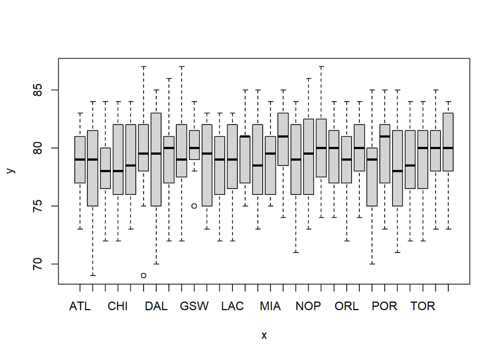

```r
nba$team = factor(nba$team)

# your code
plot(nba$team, nba$height)
```

2. a 2-column data frame with one numeric vector in the first column, and one factor in the second column: e.g. `points` and `team`

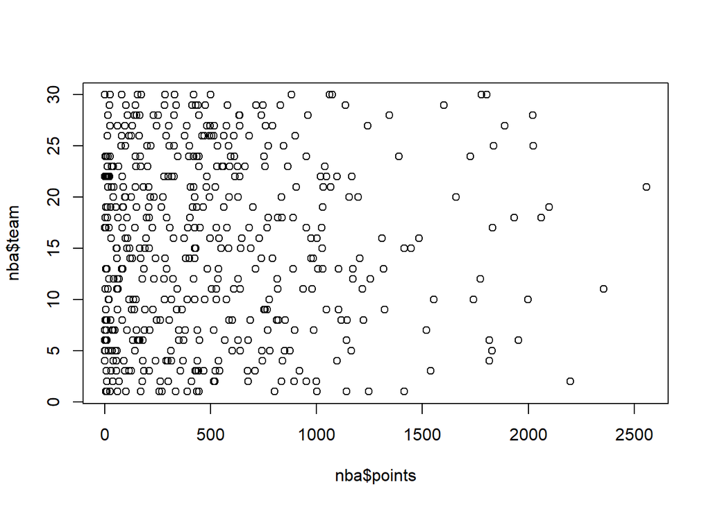

```r
# your code
plot(nba$points, nba$team)
```

3. a data frame with more than two numeric columns: `height`, `weight`, and `points`

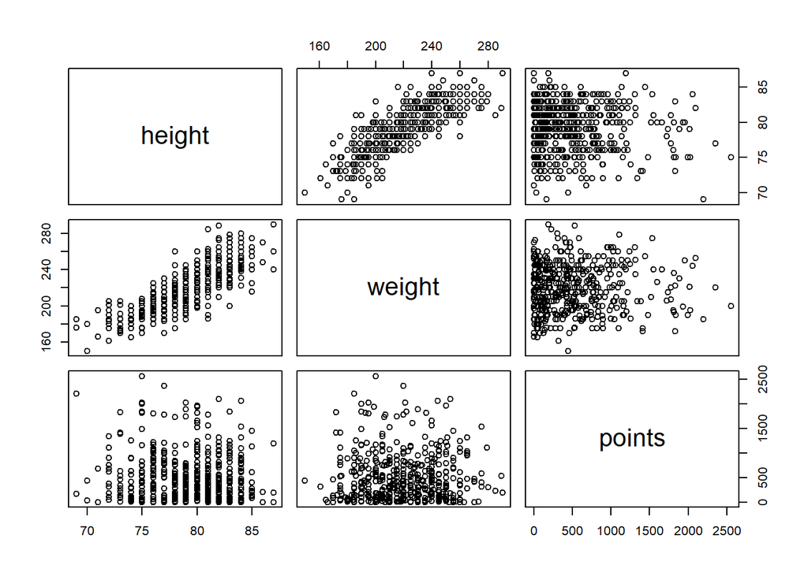

```r
# your code
plot(nba[,c("height", "weight", "points")])
```

4. invoke `plot()` to make a scatterplot of `height` and `weight`, using `position` as a `factor()` to specify colors with the argument `col`

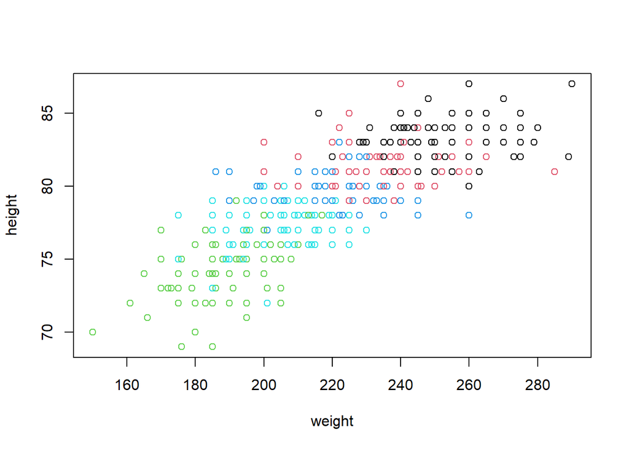

```r
# your code
plot(height ~ weight, data = nba, col = factor(position))
```